# Ocean acidification and boring sponge on *Crassostrea virginica* GE

## Gene expression plasticity

### ANOVA Tests on Plasticity Data

ANOVA test on plasticity data with 2 PCAs (looking at variable treat to see if there is any significant difference of dist)

```
##             Df Sum Sq Mean Sq F value Pr(>F)
## treat        2  348.9  174.44   1.835   0.19
## Residuals   17 1616.2   95.07
```

```
##   Tukey multiple comparisons of means
##     95% family-wise confidence level
##
## Fit: aov(formula = dist ~ treat, data = ge_plast_2)
##
## $treat
##                    diff        lwr      upr     p adj
## S_2800-N_2800  9.903288  -3.466771 23.27335 0.1689911
## S_400-N_2800   6.107834  -7.808165 20.02383 0.5117339
## S_400-S_2800  -3.795455 -17.711454 10.12054 0.7668884
```

ANOVA test on plasticity data with all PCAs (looking at variable treat to see if there is any significant difference of dist)

```
##             Df Sum Sq Mean Sq F value Pr(>F)
## treat        2   89.9   44.96   1.967   0.17
## Residuals   17  388.6   22.86
```

```
##   Tukey multiple comparisons of means
##     95% family-wise confidence level
##
## Fit: aov(formula = dist ~ treat, data = ge_plast_all)
##
## $treat
##                    diff       lwr       upr     p adj
## S_2800-N_2800  4.993713 -1.562429 11.549855 0.1542649
## S_400-N_2800   3.289942 -3.533907 10.113791 0.4485889
## S_400-S_2800  -1.703771 -8.527620  5.120078 0.8000952
```

ANOVA test on plasticity data with all PCAs (looking at variable pCO2 * infect to see if there is any significant difference of dist)

```
##             Df Sum Sq Mean Sq F value Pr(>F)
## pCO2         1    2.6    2.64   0.116 0.7381
## infect       1   87.3   87.28   3.818 0.0674 .
## Residuals   17  388.6   22.86
## ---
## Signif. codes:  0 '***' 0.001 '**' 0.01 '*' 0.05 '.' 0.1 ' ' 1
```

```
## Call:
##    aov(formula = dist ~ pCO2 * infect, data = ge_plast_all)
##
## Terms:
##                     pCO2   infect Residuals
## Sum of Squares    2.6417  87.2801  388.6136
## Deg. of Freedom        1        1        17
##
## Residual standard error: 4.781174
## 1 out of 4 effects not estimable
## Estimated effects may be unbalanced
```

```
##   Tukey multiple comparisons of means
##     95% family-wise confidence level
##
## Fit: aov(formula = dist ~ pCO2 * infect, data = ge_plast_all)
##
## $pCO2
##                diff      lwr     upr     p adj
## 2800-400 -0.7930852 -5.71523 4.12906 0.7380613
##
## $infect
##         diff       lwr      upr     p adj
## S-N 3.841318 -0.887726 8.570362 0.1047456
```

```
##             Df Sum Sq Mean Sq F value Pr(>F)
## pCO2         1    5.6     5.6   0.059 0.8109
## infect       1  343.3   343.3   3.611 0.0745 .
## Residuals   17 1616.2    95.1
## ---
## Signif. codes:  0 '***' 0.001 '**' 0.01 '*' 0.05 '.' 0.1 ' ' 1
```

```
## Call:
##    aov(formula = dist ~ pCO2 * infect, data = ge_plast_2)
##
## Terms:
##                      pCO2    infect Residuals
## Sum of Squares     5.6144  343.2629 1616.1736
## Deg. of Freedom         1         1        17
##
## Residual standard error: 9.750335
## 1 out of 4 effects not estimable
## Estimated effects may be unbalanced
```

```
##   Tukey multiple comparisons of means
##     95% family-wise confidence level
##
## Fit: aov(formula = dist ~ pCO2 * infect, data = ge_plast_2)
##
## $pCO2
##               diff       lwr     upr     p adj
## 2800-400 -1.156189 -11.19401 8.88163 0.8109013
##
## $infect
##         diff       lwr      upr     p adj
## S-N 7.617914 -2.026111 17.26194 0.1139175
```

ANOVA test on plasticity data with all PCAs (looking at variable treat to see if there is any significant difference of dist)

```
##             Df Sum Sq Mean Sq F value Pr(>F)
## treat        2   89.9   44.96   1.967   0.17
## Residuals   17  388.6   22.86
```

```
## Call:
##    aov(formula = dist ~ treat, data = ge_plast_all)
##
## Terms:
##                    treat Residuals
## Sum of Squares   89.9218  388.6136
## Deg. of Freedom        2        17
##
## Residual standard error: 4.781174
## Estimated effects may be unbalanced
```

```
##   Tukey multiple comparisons of means
##     95% family-wise confidence level
##
## Fit: aov(formula = dist ~ treat, data = ge_plast_all)
##
## $treat
##                    diff       lwr       upr     p adj
## S_2800-N_2800  4.993713 -1.562429 11.549855 0.1542649
## S_400-N_2800   3.289942 -3.533907 10.113791 0.4485889
## S_400-S_2800  -1.703771 -8.527620  5.120078 0.8000952
```

### Plasticity Plots

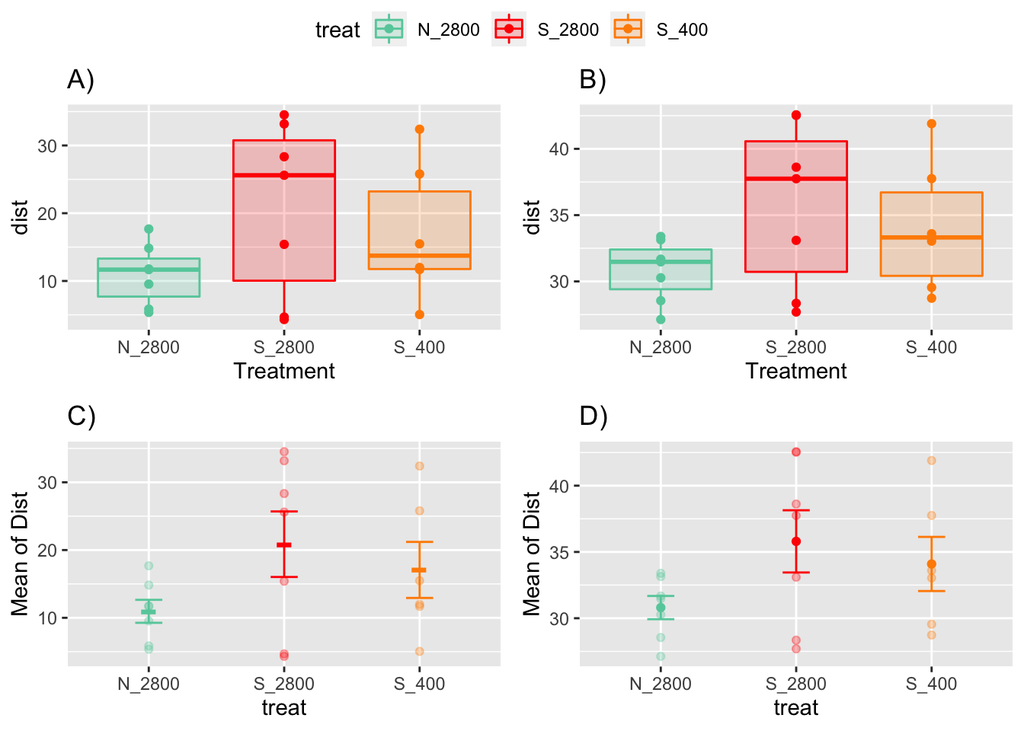